# Introducing Functions to the Workflow

Paul Apivat Hanvongse

7/30/2020

## Context

In web development, functions are everywhere and are written to get even the smallest tasks done like allowing users to click on a button or controlling where and how a pop-up modal appears. In data analysis, you can go without using functions as long as you’re working on small scale projects and do not need to share your code with others.

Moreover, they can make your life a lot easier if you want to avoid copying and pasting your code in a bunch of different places (it also makes your code less error prone and easier to update).

Functions may require a **slight** perspective shift for those who aren’t familiar. In this post, I want to share how I **snuck** functions into my workflow for a specific project.

## Slipping Custom Functions into the Workflow

The most intuitive way, in my opinion, to introduce functions is to take a certain data pre-processing sequence and **turn it into a function**. Below, I have a newly created dataframe called `net_sales_year_month` that is a dataframe with three columns (net_sales, Year, Month).

Suppose my objective is to add a `Day` and `month_year` column, that combines Year, Month and Day (yyyy-mm-dd) into a `date` type. The pre-processing task would be to take `net_sales_year_month` and use the mutate function to create some new columns.

That’s where a **custom function** comes in.

For example, the function below called `create_ymd_function` simply **replaces** `net_sales_year_month` with a generic `data`, serving as the function parameter. Now *any* dataframe can be used as a parameter for the `create_ymd_function`.

Note the BEFORE and AFTER sections below - they have the same output, but one is a more general function that can be used with other data frames.

```r
# Selecting columns to work with (net_sales)
net_sales_year_month <- retail_sales2 %>%
    select(`Net Sales`, Year, Month) %>%
    rename(net_sales = `Net Sales`)

# BEFORE
net_sales_year_month %>%
        mutate(
            Day = 1,
            month_year = paste(Year, Month, Day),
            month_year = month_year %>% ymd(),
            month = month(month_year)
        )
```

```
## # A tibble: 36 x 6
##    net_sales  Year Month       Day month_year month
##        <dbl> <dbl> <chr>     <dbl> <date>     <dbl>
##  1     8284.  2017 January       1 2017-01-01     1
##  2     6388.  2017 February      1 2017-02-01     2
##  3     4589.  2017 March         1 2017-03-01     3
##  4     8533.  2017 April         1 2017-04-01     4
##  5     6237.  2017 May           1 2017-05-01     5
##  6     9370.  2017 June          1 2017-06-01     6
##  7     5959.  2017 July          1 2017-07-01     7
##  8     7740.  2017 August        1 2017-08-01     8
##  9     6732.  2017 September     1 2017-09-01     9
## 10     5327   2017 October       1 2017-10-01    10
## # … with 26 more rows
```

```r
# AFTER

# Function takes in dataframe to add columns for further analysis
create_ymd_function <- function(data) {
    data %>%
        mutate(
            Day = 1,
            month_year = paste(Year, Month, Day),
            month_year = month_year %>% ymd(),
            month = month(month_year)
        )
}

create_ymd_function(net_sales_year_month)
```

```
## # A tibble: 36 x 6
##    net_sales  Year Month       Day month_year month
##        <dbl> <dbl> <chr>     <dbl> <date>     <dbl>
##  1     8284.  2017 January       1 2017-01-01     1
##  2     6388.  2017 February      1 2017-02-01     2
##  3     4589.  2017 March         1 2017-03-01     3
##  4     8533.  2017 April         1 2017-04-01     4
##  5     6237.  2017 May           1 2017-05-01     5
##  6     9370.  2017 June          1 2017-06-01     6
##  7     5959.  2017 July          1 2017-07-01     7
##  8     7740.  2017 August        1 2017-08-01     8
##  9     6732.  2017 September     1 2017-09-01     9
## 10     5327   2017 October       1 2017-10-01    10
## # … with 26 more rows
```

```r
net_sales_year_month_2 <- create_ymd_function(net_sales_year_month)
```

## Generalizing Functions

Here’s another example of moving from specific to *general* functions.

With the `create_line_chart` function, i’m taking in a dataframe, piping into `ggplot` and visualizing a simple line graph with `geom_line`. You’ll note it is specific because it requires the dataframe to have a column named `net_sales` in order to work.

But what if I wanted to repeat this operation with `total_orders` or `total_sales` or some other metric?

Right below, I create a more *general* function, `create_line_chart_general` that takes in *any* dataset and two columns as the function parameter.

This makes the function much more re-usable. However, it also introduces some `R`-specific commands like `enquo()` and `!!` to *quote* and *unquote* parameters for use in the function. We are entering `lazy evaluation` territory, which I’ll save for another post!

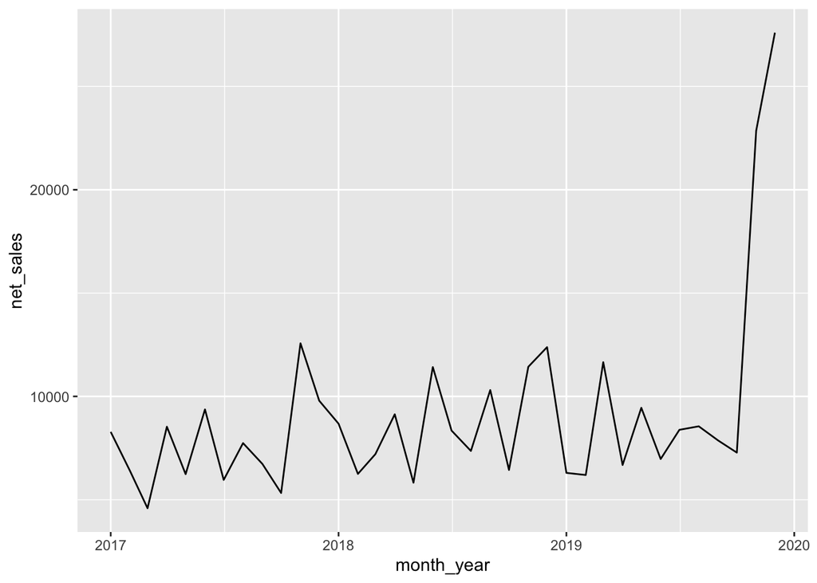

```r
# BEFORE:

# This function only works for net_sales
# It's easy to just slip 'data' as an argument
# But the aesthetic mapping is done only one a specific column
create_line_chart <- function(data){
    data %>%
    ggplot(aes(x = month_year, y = net_sales)) +
    geom_line()
}

# AFTER:

# This is a more generalizable function using enquo() and '!!'
# note columns as function parameters

create_line_chart_general <- function(dataset, col_name_1, col_name_2){
    col_name_1 <- enquo(col_name_1)
    col_name_2 <- enquo(col_name_2)
    dataset %>%
        ggplot(aes(x = !!(col_name_1), y = !!(col_name_2))) +
        geom_line()
}

# Call the function with data and necessary parameters
create_line_chart_general(net_sales_year_month_2, month_year, net_sales)
```

## More Generalized Function

This next function is slightly more complicated as it involves creating several more columns. But it can still be generalized using the tools discussed above.

```r
create_bpc_columns_general <- function(dataset, col_name){
    col_name <- enquo(col_name)
    bpc_data <- dataset %>%
        mutate(
            avg_orders = mean(!!(col_name)),
            # calculate lagging difference
            moving_range = diff(as.zoo(!!(col_name)), na.pad=TRUE),
            # get absolute value
            moving_range = abs(moving_range),
            # change NA to 0
            moving_range = ifelse(row_number()==1, 0, moving_range),
            avg_moving_range = mean(moving_range),
            lnpl = avg_orders - (2.66*avg_moving_range),
            lower_25 = avg_orders - (1.33*avg_moving_range),
            upper_25 = avg_orders + (1.33*avg_moving_range),
            unpl = avg_orders + (2.66*avg_moving_range)
        )

    return(bpc_data)
}

create_bpc_columns_general(net_sales_year_month_2, net_sales)
```

```
## # A tibble: 36 x 13
##    net_sales  Year Month   Day month_year month avg_orders moving_range
##        <dbl> <dbl> <chr> <dbl> <date>     <dbl>      <dbl>        <dbl>
##  1     8284.  2017 Janu…     1 2017-01-01     1      9058.           0
##  2     6388.  2017 Febr…     1 2017-02-01     2      9058.        1896.
##  3     4589.  2017 March     1 2017-03-01     3      9058.        1798.
##  4     8533.  2017 April     1 2017-04-01     4      9058.        3944.
##  5     6237.  2017 May       1 2017-05-01     5      9058.        2295.
##  6     9370.  2017 June      1 2017-06-01     6      9058.        3132.
##  7     5959.  2017 July      1 2017-07-01     7      9058.        3410.
##  8     7740.  2017 Augu…     1 2017-08-01     8      9058.        1781.
##  9     6732.  2017 Sept…     1 2017-09-01     9      9058.        1008.
## 10     5327   2017 Octo…     1 2017-10-01    10      9058.        1405.
## # … with 26 more rows, and 5 more variables: avg_moving_range <dbl>,
## #   lnpl <dbl>, lower_25 <dbl>, upper_25 <dbl>, unpl <dbl>
```

```r
net_sales_bpc_data <- create_bpc_columns_general(net_sales_year_month_2, net_sales)
```

## Generalized Functions for Visualization

This was the trickiest to convert into a general function and I’m still on the fence as to whether this is generalizable. In one sense, it *is* generalizable as I tested this `create_bpc_visualization_general` function on another column aside from `net_sales`, but it did require that I *know* that other columns in the dataset are: `avg_orders`, `unpl`, `lnpl`, `upper_25` and `lower_25`.

I have more exploring to do around quoting and unquoting `enquo()`, `quos()` for various `ggplot` geometries like `geom_hline`. Will report back with another post once I get those details down.

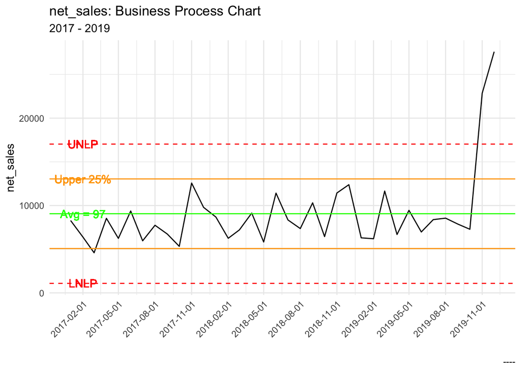

```r
create_bpc_visualization_general <- function(dataset, col_x, col_y, col_avg, col_unpl, col_lnpl, col_upper_25, col_lower_25){
    col_x <- enquo(col_x) # month_year
    col_y <- enquo(col_y) # net_sales

    col_avg <- dataset$avg_orders
    col_unpl <- dataset$unpl
    col_lnpl <- dataset$lnpl
    col_upper_25 <- dataset$upper_25
    col_lower_25 <- dataset$lower_25

    dataset %>%
        ggplot(aes(x = !!(col_x), y = !!(col_y))) +
        geom_line() +
        geom_hline(yintercept = col_avg, color = 'green') +
        geom_hline(yintercept = col_unpl, color = 'red', linetype = 'dashed') +
        geom_hline(yintercept = col_lnpl, color = 'red', linetype = 'dashed') +
        geom_hline(yintercept = col_upper_25, color = 'orange') +
        geom_hline(yintercept = col_lower_25, color = 'orange') +

        # break x-axis into quarters
        scale_x_date(breaks = '3 month') +
        # note: place before theme()
        theme_minimal() +
        theme(axis.text.x = element_text(angle = 45, hjust = 1)) +
        labs(
            title = glue('{names(dataset[,1])}: Business Process Chart'),
            subtitle = "2017 - 2019",
            x = "",
            y = glue('{names(dataset[,1])}'),
            caption = "----"
        ) +
        annotate("text", x = as.Date("2017-02-01"), y = col_unpl, color = 'red', label = "UNLP") +
        annotate("text", x = as.Date("2017-02-01"), y = col_lnpl, color = 'red', label = "LNLP") +
        annotate("text", x = as.Date("2017-02-01"), y = col_upper_25, color = 'orange', label = "Upper 25%") +
        annotate("text", x = as.Date("2017-02-01"), y = col_avg, color = 'green', label = "Avg = 97")

}

create_bpc_visualization_general(net_sales_bpc_data, month_year, net_sales, avg_orders, unpl, lnpl, upper_25, lower_25)
```

## Summary

It’s possible to do a fair amount of data analysis without using functions, but **functions** help you avoid endless copying and pasting and make your code less error prone.

There are many different types functions you could use. In this post, I share functions that take columns of data as arguments. These types of functions are well-suited for streamlining your data pre-processing and visualization tasks.

Shout out to [Bruno Rodrigues](https://twitter.com/brodriguesco) for writing [**Modern R with the Tidyverse**](https://b-rodrigues.github.io/modern_R/) which has helped me get my head around writing custom functions.